# CITS4009-project2

#### 4.5.3.2 Build Logistic Regression model for feature combination 2

```r
lrmodel2 <- glm(as.formula(paste("earning_class ~ ", paste(feature_combine2, collapse = ' + '))), data = youtube_train, family = "binomial")
```

Check the Model Performance

```r
# train set AUC score
lrmodel2_train_auc <- AUC_calculator(predict(lrmodel2, newdata=youtube_train), youtube_train[,target_column])
cat('lrmodel2\'s AUC score on the training set is',lrmodel2_train_auc, "\n")
```

```
## lrmodel2's AUC score on the training set is 0.9497706
```

```r
# test set AUC score
lrmodel2_test_auc <- AUC_calculator(predict(lrmodel2, newdata=youtube_test), youtube_test[,target_column])
cat('lrmodel2\'s AUC score on the testing set is',lrmodel2_test_auc)
```

```
## lrmodel2's AUC score on the testing set is 0.9457014
```

```r
# performance table
pretty_perf_table(lrmodel2,youtube_train[feature_combine2],youtube_train[,target_column] == positive_label,youtube_test[feature_combine2],youtube_test[,target_column] == positive_label)
```

```
##
##
## model                   precision   recall       f1   dev.norm
## --------------------- ----------- -------- -------- ----------
## lrmodel2 , training        0.8911   0.5921   0.7115     -2.509
## lrmodel2 , testing         0.7500   0.6176   0.6774     -2.174
```

```r
# log likelihood
cat("lrmodel2 Log Likelihood:", calculateLogLikelihood(lrmodel2, youtube_test, positive_label, epsilon = 1e-6), "\n")
```

```
## lrmodel2 Log Likelihood: NaN
```

```r
cat("NULL model Log Likelihood:",logNull)
```

```
## NULL model Log Likelihood: -380.3058
```

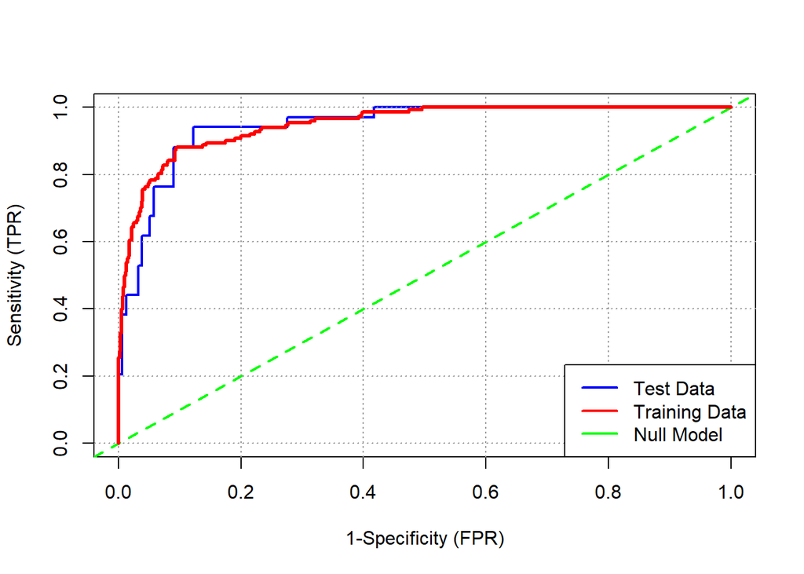

```r
# print ROC plot
pred_test_roc_lrmodel2 <- predict(lrmodel2, newdata=youtube_test)
pred_train_roc_lrmodel2 <- predict(lrmodel2, newdata=youtube_train)
plot_roc2(pred_test_roc_lrmodel2, youtube_test[[target_column]],
         pred_train_roc_lrmodel2, youtube_train[[target_column]])
```

Although the AUC value of The ‘Logistic Regression with feature combination 2’ model is not bad at 0.949, the precision is a bit low at only 0.89, which means that false positives are more likely to occur. The recall rate is also a bit low at only 0.59, which means that the model cannot capture it correctly. Most of the positive categories, and the log-likelihood value cannot be calculated, so the model cannot predict well.